# Summary

# Stage 3: Process

#### "No data is clean, but most is useful" - Dean Abbott

**Task 1:** Clean and process data- Before I could perform analysis, I needed my values to be in a usable format. I filled in missing values....

With a single row (house) serving as a unit of replication, I wanted rows to have all future classification variables listed in separate columns so I could group them later on.

```python
train = pd.read_csv('C:/Users/hoper/Untitled Folder/train.csv', on_bad_lines='skip')
test = pd.read_csv('C:/Users/hoper/Untitled Folder/test.csv', on_bad_lines='skip')
```

```python
# Success
print("Train dataset has {} values with {} variables each.".format(*train.shape))
print("Test dataset has {} values with {} variables each.".format(*test.shape))
```

```
Train dataset has 1460 values with 81 variables each.
Test dataset has 1459 values with 80 variables each.
```

```python
train.describe(include = 'all')
```

|  | Id | MSSubClass | MSZoning | LotFrontage | LotArea | Street | Alley | LotShape | LandContour | Utilities | LotConfig | LandSlope | Neighborhood | Condition1 | Condition2 | BldgType | HouseStyle | OverallQual | OverallCond | YearBuilt | YearRemodAdd | RoofStyle | RoofMatl | Exterior1st | Exterior2nd | MasVnrType | MasVnrArea | ExterQual | ExterCond | … |
| --- | --- | --- | --- | --- | --- | --- | --- | --- | --- | --- | --- | --- | --- | --- | --- | --- | --- | --- | --- | --- | --- | --- | --- | --- | --- | --- | --- | --- | --- | --- |
| count | 1460.000000 | 1460.000000 | 1460 | 1201.000000 | 1460.000000 | 1460 | 91 | 1460 | 1460 | 1460 | 1460 | 1460 | 1460 | 1460 | 1460 | 1460 | 1460 | 1460.000000 | 1460.000000 | 1460.000000 | 1460.000000 | 1460 | 1460 | 1460 | 1460 | 1452 | 1452.000000 | 1460 | 1460 | … |
| unique | NaN | NaN | 5 | NaN | NaN | 2 | 2 | 4 | 4 | 2 | 5 | 3 | 25 | 9 | 8 | 5 | 8 | NaN | NaN | NaN | NaN | 6 | 8 | 15 | 16 | 4 | NaN | 4 | 5 | … |
| top | NaN | NaN | RL | NaN | NaN | Pave | Grvl | Reg | Lvl | AllPub | Inside | Gtl | NAmes | Norm | Norm | 1Fam | 1Story | NaN | NaN | NaN | NaN | Gable | CompShg | VinylSd | VinylSd | None | NaN | TA | TA | … |
| freq | NaN | NaN | 1151 | NaN | NaN | 1454 | 50 | 925 | 1311 | 1459 | 1052 | 1382 | 225 | 1260 | 1445 | 1220 | 726 | NaN | NaN | NaN | NaN | 1141 | 1434 | 515 | 504 | 864 | NaN | 906 | 1282 | … |
| mean | 730.500000 | 56.897260 | NaN | 70.049958 | 10516.828082 | NaN | NaN | NaN | NaN | NaN | NaN | NaN | NaN | NaN | NaN | NaN | NaN | 6.099315 | 5.575342 | 1971.267808 | 1984.865753 | NaN | NaN | NaN | NaN | NaN | 103.685262 | NaN | NaN | … |
| std | 421.610009 | 42.300571 | NaN | 24.284752 | 9981.264932 | NaN | NaN | NaN | NaN | NaN | NaN | NaN | NaN | NaN | NaN | NaN | NaN | 1.382997 | 1.112799 | 30.202904 | 20.645407 | NaN | NaN | NaN | NaN | NaN | 181.066207 | NaN | NaN | … |
| min | 1.000000 | 20.000000 | NaN | 21.000000 | 1300.000000 | NaN | NaN | NaN | NaN | NaN | NaN | NaN | NaN | NaN | NaN | NaN | NaN | 1.000000 | 1.000000 | 1872.000000 | 1950.000000 | NaN | NaN | NaN | NaN | NaN | 0.000000 | NaN | NaN | … |
| 25% | 365.750000 | 20.000000 | NaN | 59.000000 | 7553.500000 | NaN | NaN | NaN | NaN | NaN | NaN | NaN | NaN | NaN | NaN | NaN | NaN | 5.000000 | 5.000000 | 1954.000000 | 1967.000000 | NaN | NaN | NaN | NaN | NaN | 0.000000 | NaN | NaN | … |
| 50% | 730.500000 | 50.000000 | NaN | 69.000000 | 9478.500000 | NaN | NaN | NaN | NaN | NaN | NaN | NaN | NaN | NaN | NaN | NaN | NaN | 6.000000 | 5.000000 | 1973.000000 | 1994.000000 | NaN | NaN | NaN | NaN | NaN | 0.000000 | NaN | NaN | … |
| 75% | 1095.250000 | 70.000000 | NaN | 80.000000 | 11601.500000 | NaN | NaN | NaN | NaN | NaN | NaN | NaN | NaN | NaN | NaN | NaN | NaN | 7.000000 | 6.000000 | 2000.000000 | 2004.000000 | NaN | NaN | NaN | NaN | NaN | 166.000000 | NaN | NaN | … |
| max | 1460.000000 | 190.000000 | NaN | 313.000000 | 215245.000000 | NaN | NaN | NaN | NaN | NaN | NaN | NaN | NaN | NaN | NaN | NaN | NaN | 10.000000 | 9.000000 | 2010.000000 | 2010.000000 | NaN | NaN | NaN | NaN | NaN | 1600.000000 | NaN | NaN | … |

```python
test.describe(include = 'all')
```

|  | Id | MSSubClass | MSZoning | LotFrontage | LotArea | Street | Alley | LotShape | LandContour | Utilities | LotConfig | LandSlope | Neighborhood | Condition1 | Condition2 | BldgType | HouseStyle | OverallQual | OverallCond | YearBuilt | YearRemodAdd | RoofStyle | RoofMatl | Exterior1st | Exterior2nd | MasVnrType | MasVnrArea | ExterQual | ExterCond | … |
| --- | --- | --- | --- | --- | --- | --- | --- | --- | --- | --- | --- | --- | --- | --- | --- | --- | --- | --- | --- | --- | --- | --- | --- | --- | --- | --- | --- | --- | --- | --- |
| count | 1459.000000 | 1459.000000 | 1455 | 1232.000000 | 1459.000000 | 1459 | 107 | 1459 | 1459 | 1457 | 1459 | 1459 | 1459 | 1459 | 1459 | 1459 | 1459 | 1459.000000 | 1459.000000 | 1459.000000 | 1459.000000 | 1459 | 1459 | 1458 | 1458 | 1443 | 1444.000000 | 1459 | 1459 | … |
| unique | NaN | NaN | 5 | NaN | NaN | 2 | 2 | 4 | 4 | 1 | 5 | 3 | 25 | 9 | 5 | 5 | 7 | NaN | NaN | NaN | NaN | 6 | 4 | 13 | 15 | 4 | NaN | 4 | 5 | … |
| top | NaN | NaN | RL | NaN | NaN | Pave | Grvl | Reg | Lvl | AllPub | Inside | Gtl | NAmes | Norm | Norm | 1Fam | 1Story | NaN | NaN | NaN | NaN | Gable | CompShg | VinylSd | VinylSd | None | NaN | TA | TA | … |
| freq | NaN | NaN | 1114 | NaN | NaN | 1453 | 70 | 934 | 1311 | 1457 | 1081 | 1396 | 218 | 1251 | 1444 | 1205 | 745 | NaN | NaN | NaN | NaN | 1169 | 1442 | 510 | 510 | 878 | NaN | 892 | 1256 | … |
| mean | 2190.000000 | 57.378341 | NaN | 68.580357 | 9819.161069 | NaN | NaN | NaN | NaN | NaN | NaN | NaN | NaN | NaN | NaN | NaN | NaN | 6.078821 | 5.553804 | 1971.357779 | 1983.662783 | NaN | NaN | NaN | NaN | NaN | 100.709141 | NaN | NaN | … |
| std | 421.321334 | 42.746880 | NaN | 22.376841 | 4955.517327 | NaN | NaN | NaN | NaN | NaN | NaN | NaN | NaN | NaN | NaN | NaN | NaN | 1.436812 | 1.113740 | 30.390071 | 21.130467 | NaN | NaN | NaN | NaN | NaN | 177.625900 | NaN | NaN | … |
| min | 1461.000000 | 20.000000 | NaN | 21.000000 | 1470.000000 | NaN | NaN | NaN | NaN | NaN | NaN | NaN | NaN | NaN | NaN | NaN | NaN | 1.000000 | 1.000000 | 1879.000000 | 1950.000000 | NaN | NaN | NaN | NaN | NaN | 0.000000 | NaN | NaN | … |
| 25% | 1825.500000 | 20.000000 | NaN | 58.000000 | 7391.000000 | NaN | NaN | NaN | NaN | NaN | NaN | NaN | NaN | NaN | NaN | NaN | NaN | 5.000000 | 5.000000 | 1953.000000 | 1963.000000 | NaN | NaN | NaN | NaN | NaN | 0.000000 | NaN | NaN | … |
| 50% | 2190.000000 | 50.000000 | NaN | 67.000000 | 9399.000000 | NaN | NaN | NaN | NaN | NaN | NaN | NaN | NaN | NaN | NaN | NaN | NaN | 6.000000 | 5.000000 | 1973.000000 | 1992.000000 | NaN | NaN | NaN | NaN | NaN | 0.000000 | NaN | NaN | … |
| 75% | 2554.500000 | 70.000000 | NaN | 80.000000 | 11517.500000 | NaN | NaN | NaN | NaN | NaN | NaN | NaN | NaN | NaN | NaN | NaN | NaN | 7.000000 | 6.000000 | 2001.000000 | 2004.000000 | NaN | NaN | NaN | NaN | NaN | 164.000000 | NaN | NaN | … |
| max | 2919.000000 | 190.000000 | NaN | 200.000000 | 56600.000000 | NaN | NaN | NaN | NaN | NaN | NaN | NaN | NaN | NaN | NaN | NaN | NaN | 10.000000 | 9.000000 | 2010.000000 | 2010.000000 | NaN | NaN | NaN | NaN | NaN | 1290.000000 | NaN | NaN | … |

### 3.1 Drop Not Relevant Variables, Find Data Class

```python
# drop the house id column because it is not useful for analysis:
#1. Save the 'Id' column
train_ID = train['Id']
test_ID = test['Id']

#2. drop the  'Id' column
train.drop("Id", axis = 1, inplace = True)
test.drop("Id", axis = 1, inplace = True)
```

```python
# verify data class and structure
train.info()
test.info()
```

```
<class 'pandas.core.frame.DataFrame'>
RangeIndex: 1460 entries, 0 to 1459
Data columns (total 80 columns):
 #   Column         Non-Null Count  Dtype
---  ------         --------------  -----
 0   MSSubClass     1460 non-null   int64
 1   MSZoning       1460 non-null   object
 2   LotFrontage    1201 non-null   float64
 3   LotArea        1460 non-null   int64
 4   Street         1460 non-null   object
 5   Alley          91 non-null     object
 6   LotShape       1460 non-null   object
 7   LandContour    1460 non-null   object
 8   Utilities      1460 non-null   object
 9   LotConfig      1460 non-null   object
```

[output cut: 158 more lines]

### 3.2 Replacing missing values

These datasets had many missing values. It is important to account for missing values to minimize noise in the machine learning model. I needed to identify the type of missing data, the extent of the problem, and to verify the context of each value within the data description.

To do this, I first counted the missing values by factor in each dataset.

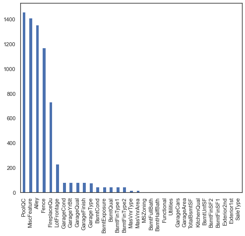

```python
# count NA's test
test_na_total = test.isnull().sum()
test_na_sort = test_na_total[test_na_total>0].sort_values(ascending=False)
sns.set_style("white")
f, ax = plt.subplots(figsize=(8, 7))
test_na_sort.plot.bar(color="b")
```

Figure 1: Frequency of missing values within the test dataset.

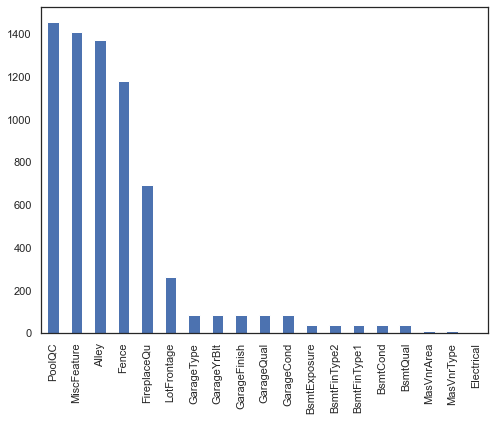

```python
# count NA's train
train_na_total = train.isnull().sum()
train_na_sort = train_na_total[train_na_total>0].sort_values(ascending=False)
sns.set_style("white")
f, ax = plt.subplots(figsize=(8, 6))
train_na_sort.plot.bar(color="b")
```

Figure 2: Frequency of missing values within the train dataset.

```python
# replace missing values according to each variable's data description or imputation

#PoolQC- data description lists NA as "No Pool"
test["PoolQC"] = test["PoolQC"].fillna("None")
train["PoolQC"] = train["PoolQC"].fillna("None")

#MiscFeature- data description lists NA as "no misc feature"
test["MiscFeature"] = test["MiscFeature"].fillna("None")
train["MiscFeature"] = train["MiscFeature"].fillna("None")

#Alley- data description lists NA as "no alley access"
test["Alley"] = test["Alley"].fillna("None")
train["Alley"] = train["Alley"].fillna("None")

#Fence- data description lists NA as "no fence"
test["Fence"] = test["Fence"].fillna("None")
train["Fence"] = train["Fence"].fillna("None")

#FireplaceQu- data description lists NA as "no fireplace"
test["FireplaceQu"] = test["FireplaceQu"].fillna("None")
train["FireplaceQu"] = train["FireplaceQu"].fillna("None")

#LotFrontage- fill missing lot values by median lot frontage of the respective neighborhood.
test["LotFrontage"] = test.groupby("Neighborhood")["LotFrontage"].transform(
    lambda x: x.fillna(x.median()))
train["LotFrontage"] = train.groupby("Neighborhood")["LotFrontage"].transform(
    lambda x: x.fillna(x.median()))

#GarageType, GarageFinish, GarageQual and GarageCond- Replacing missing data with None
for col in ('GarageType', 'GarageFinish', 'GarageQual', 'GarageCond'):
    test[col] = test[col].fillna('None')
for col in ('GarageType', 'GarageFinish', 'GarageQual', 'GarageCond'):
    train[col] = train[col].fillna('None')

#GarageYrBlt, GarageArea and GarageCars- no garage, replace missing data with 0
for col in ('GarageYrBlt', 'GarageArea', 'GarageCars'):
    test[col] = test[col].fillna(0)
for col in ('GarageYrBlt', 'GarageArea', 'GarageCars'):
    train[col] = train[col].fillna(0)

#BsmtFinSF1, BsmtFinSF2, BsmtUnfSF, TotalBsmtSF, BsmtFullBath and BsmtHalfBath- no basement, replace missing values with 0
for col in ('BsmtFinSF1', 'BsmtFinSF2', 'BsmtUnfSF','TotalBsmtSF', 'BsmtFullBath', 'BsmtHalfBath'):
    test[col] = test[col].fillna(0)
for col in ('BsmtFinSF1', 'BsmtFinSF2', 'BsmtUnfSF','TotalBsmtSF', 'BsmtFullBath', 'BsmtHalfBath'):
    train[col] = train[col].fillna(0)

#BsmtQual, BsmtCond, BsmtExposure, BsmtFinType1 and BsmtFinType2- NaN lists as no basement
for col in ('BsmtQual', 'BsmtCond', 'BsmtExposure', 'BsmtFinType1', 'BsmtFinType2'):
    test[col] = test[col].fillna('None')
for col in ('BsmtQual', 'BsmtCond', 'BsmtExposure', 'BsmtFinType1', 'BsmtFinType2'):
    train[col] = train[col].fillna('None')

#MasVnrArea and MasVnrType- NA lists as no masonry veneer, area = 0, type = None
test["MasVnrType"] = test["MasVnrType"].fillna("None")
test["MasVnrArea"] = test["MasVnrArea"].fillna(0)
train["MasVnrType"] = train["MasVnrType"].fillna("None")
train["MasVnrArea"] = train["MasVnrArea"].fillna(0)

#MSZoning (The general zoning classification)-
# Assumption: fill in with 'RL', most common zoning type
test['MSZoning'] = test['MSZoning'].fillna(test['MSZoning'].mode()[0])
train['MSZoning'] = train['MSZoning'].fillna(train['MSZoning'].mode()[0])

#Functional- data description lists NA as typical
test["Functional"] = test["Functional"].fillna("Typ")
train["Functional"] = train["Functional"].fillna("Typ")

#Electrical- Missing 1 value. Assumption: fill in with 'SBrkr', most common electrical type
test['Electrical'] = test['Electrical'].fillna(test['Electrical'].mode()[0])
train['Electrical'] = train['Electrical'].fillna(train['Electrical'].mode()[0])

#KitchenQual- Missing 1 value. Assumption: fill in with 'TA', most common KitchenQual type.
test['KitchenQual'] = test['KitchenQual'].fillna(test['KitchenQual'].mode()[0])
train['KitchenQual'] = train['KitchenQual'].fillna(train['KitchenQual'].mode()[0])

#Exterior1st and Exterior2nd- Missing 1 value. Assumption: fill in with most common exterior type
test['Exterior1st'] = test['Exterior1st'].fillna(test['Exterior1st'].mode()[0])
test['Exterior2nd'] = test['Exterior2nd'].fillna(test['Exterior2nd'].mode()[0])
train['Exterior1st'] = train['Exterior1st'].fillna(train['Exterior1st'].mode()[0])
train['Exterior2nd'] = train['Exterior2nd'].fillna(train['Exterior2nd'].mode()[0])

#SaleType- Missing 1 value. Assumption: fill in with "WD", the most frequent sale type
test['SaleType'] = test['SaleType'].fillna(test['SaleType'].mode()[0])
train['SaleType'] = train['SaleType'].fillna(train['SaleType'].mode()[0])

#MSSubClass- Na lists as no building class, replace missing values with None
test['MSSubClass'] = test['MSSubClass'].fillna("None")
train['MSSubClass'] = train['MSSubClass'].fillna("None")
```

```python
# verify that NA's were replaced
test_total = test.isnull().sum()
test_total[test_total>0].sort_values(ascending=False)

train_total = train.isnull().sum()
train_total[train_total>0].sort_values(ascending=False)
```

```
Series([], dtype: int64)
```